# FIFA+World+Cup+Student+Version

------------------

------------------ FIFA World Cup

Dataset Information:-

The FIFA World Cup is a global football competition contested by the various football-playing nations of the world. It is contested every four years and is the most prestigious and important trophy in the sport of football.

The FIFA World Cup, often simply called the World Cup, is an international association football competition contested by the senior men's national teams of the members of the Fédération Internationale de Football Association (FIFA), the sport's global governing body. The championship has been awarded every four years since the inaugural tournament in 1930, except in 1942 and 1946 when it was not held because of the Second World War.

The World Cups dataset shows all information about all the World Cups in history till 2014, while the World Cup Matches dataset shows all the results from the matches contested as part of the cups.

Problem Statement:-

A new football club named ‘Brussels United FC’ has just been inaugurated. As a member of this club, you have been assigned a task to carry analysis on matches, players, and world cup data. Here we need to analyze the countries which have won the world cup the most with attendance, goal, and matches per cup based on cities. Also distribution of home and away goals. Whether playing in the home country is a factor for winning or not?

**Questions to answer-**

- Total goals scored by year
- Total matches played and qualified teams by year
- Matches with the highest number of attendance
- Cities that hosted highest world cup matches
- Average attendance by city
- Teams with the most world cup final victories
- World cup final results by nation
- Match outcomes by home and away teams

Data Definition:-

1. World Cup Matches Dataset

**Year**: The year in which the match was played

**Datetime**: The Date on which the match was played along with a 24 hour format time

**Stage**: The stage at which the match was played

**Stadium**: Stadium name where the match was held

**City**: The city name, where the match was played

**Home Team Name**: Home team country name

**Home Team Goals**: Total goals scored by the home team by the end of the match

**Away Team Goals**: Total goals scored by the away team by the end of the match

**Away Team Name**: Away team country name

**Win conditions**: Special win condition (if any)

**Attendance**: Total crowd present at the stadium

**Half-time Home Goals**: Goals scored by the home team until half time

**Half-time Away Goals**: Goals scored by the away team until half time

**Referee**: Name of the first referee

**Assistant 1**: Name of the first assistant referee (linesman)

**Assistant 2**: Name of the second assistant referee (linesman)

**RoundID**: Unique ID of the Round

**MatchID**: Unique ID of the Match

**Home Team Initials**: Home team country's three letter initials

**Away Team Initials**: Away team country's three left

2. World Cup Players Dataset

**RoundID**: Unique ID of the Round

**MatchID**: Unique ID of the Match

**Team Initials**: Player's team country's three letter initials

**Coach Name**: Player's coach name

**Line-up**: Indicates whether the player was in the starting line-up or not

**Shirt Number**: Player's shirt number

**Player Name**: Player's name

**Position**: Position that the player played in

**Event**: Important event involving the player (if any)

3. World Cup Dataset

**Year**: Year in which the world cup was held

**Country**: Country where the world cup was held

**Winner**: Team that won the world cup

**Runners-Up**: Team that came second

**Third**: Team that came third

**Fourth**: Team that came fourth

**GoalsScored**: Total goals scored in the world cup

**QualifiedTeams**: Number of teams that qualified for the world cup

**MatchesPlayed**: Total matches played in the world cup

**Attendance**: Total attendance in the world cup

```python
# import neccessary libraries and ignore warnings
import pandas as pd
import numpy as np
import matplotlib.pyplot as plt
import seaborn as sns
import warnings

warnings.filterwarnings("ignore")
```

```python
cups=pd.read_csv('WorldCups.csv')
players=pd.read_csv('WorldCupPlayers.csv')
matches=pd.read_csv('WorldCupMatches.csv')
```

```python
cups.head(5)
```

|  | Year | Country | Winner | Runners-Up | Third | Fourth | GoalsScored | QualifiedTeams | MatchesPlayed | Attendance |
| --- | --- | --- | --- | --- | --- | --- | --- | --- | --- | --- |
| 0 | 1930 | Uruguay | Uruguay | Argentina | USA | Yugoslavia | 70 | 13 | 18 | 590.549 |
| 1 | 1934 | Italy | Italy | Czechoslovakia | Germany | Austria | 70 | 16 | 17 | 363.000 |
| 2 | 1938 | France | Italy | Hungary | Brazil | Sweden | 84 | 15 | 18 | 375.700 |
| 3 | 1950 | Brazil | Uruguay | Brazil | Sweden | Spain | 88 | 13 | 22 | 1.045.246 |
| 4 | 1954 | Switzerland | Germany FR | Hungary | Austria | Uruguay | 140 | 16 | 26 | 768.607 |

```python
players.head()
```

|  | RoundID | MatchID | Team Initials | Coach Name | Line-up | Shirt Number | Player Name | Position | Event |
| --- | --- | --- | --- | --- | --- | --- | --- | --- | --- |
| 0 | 201 | 1096 | FRA | CAUDRON Raoul (FRA) | S | 0 | Alex THEPOT | GK | NaN |
| 1 | 201 | 1096 | MEX | LUQUE Juan (MEX) | S | 0 | Oscar BONFIGLIO | GK | NaN |
| 2 | 201 | 1096 | FRA | CAUDRON Raoul (FRA) | S | 0 | Marcel LANGILLER | NaN | G40' |
| 3 | 201 | 1096 | MEX | LUQUE Juan (MEX) | S | 0 | Juan CARRENO | NaN | G70' |
| 4 | 201 | 1096 | FRA | CAUDRON Raoul (FRA) | S | 0 | Ernest LIBERATI | NaN | NaN |

```python
matches.head()
```

|  | Year | Datetime | Stage | Stadium | City | Home Team Name | Home Team Goals | Away Team Goals | Away Team Name | Win conditions | Attendance | Half-time Home Goals | Half-time Away Goals | Referee | Assistant 1 | Assistant 2 | RoundID | MatchID | Home Team Initials | Away Team Initials |
| --- | --- | --- | --- | --- | --- | --- | --- | --- | --- | --- | --- | --- | --- | --- | --- | --- | --- | --- | --- | --- |
| 0 | 1930.0 | 13 Jul 1930 - 15:00 | Group 1 | Pocitos | Montevideo | France | 4.0 | 1.0 | Mexico |  | 4444.0 | 3.0 | 0.0 | LOMBARDI Domingo (URU) | CRISTOPHE Henry (BEL) | REGO Gilberto (BRA) | 201.0 | 1096.0 | FRA | MEX |
| 1 | 1930.0 | 13 Jul 1930 - 15:00 | Group 4 | Parque Central | Montevideo | USA | 3.0 | 0.0 | Belgium |  | 18346.0 | 2.0 | 0.0 | MACIAS Jose (ARG) | MATEUCCI Francisco (URU) | WARNKEN Alberto (CHI) | 201.0 | 1090.0 | USA | BEL |
| 2 | 1930.0 | 14 Jul 1930 - 12:45 | Group 2 | Parque Central | Montevideo | Yugoslavia | 2.0 | 1.0 | Brazil |  | 24059.0 | 2.0 | 0.0 | TEJADA Anibal (URU) | VALLARINO Ricardo (URU) | BALWAY Thomas (FRA) | 201.0 | 1093.0 | YUG | BRA |
| 3 | 1930.0 | 14 Jul 1930 - 14:50 | Group 3 | Pocitos | Montevideo | Romania | 3.0 | 1.0 | Peru |  | 2549.0 | 1.0 | 0.0 | WARNKEN Alberto (CHI) | LANGENUS Jean (BEL) | MATEUCCI Francisco (URU) | 201.0 | 1098.0 | ROU | PER |
| 4 | 1930.0 | 15 Jul 1930 - 16:00 | Group 1 | Parque Central | Montevideo | Argentina | 1.0 | 0.0 | France |  | 23409.0 | 0.0 | 0.0 | REGO Gilberto (BRA) | SAUCEDO Ulises (BOL) | RADULESCU Constantin (ROU) | 201.0 | 1085.0 | ARG | FRA |

```python
matches.dtypes
```

```
Year                    float64
Datetime                 object
Stage                    object
Stadium                  object
City                     object
Home Team Name           object
Home Team Goals         float64
Away Team Goals         float64
Away Team Name           object
Win conditions           object
Attendance              float64
Half-time Home Goals    float64
Half-time Away Goals    float64
Referee                  object
Assistant 1              object
Assistant 2              object
RoundID                 float64
MatchID                 float64
Home Team Initials       object
Away Team Initials       object
dtype: object
```

```python
players.describe().T
```

|  | count | mean | std | min | 25% | 50% | 75% | max |
| --- | --- | --- | --- | --- | --- | --- | --- | --- |
| RoundID | 37784.0 | 1.105647e+07 | 2.770144e+07 | 201.0 | 263.0 | 337.0 | 255931.0 | 97410600.0 |
| MatchID | 37784.0 | 6.362233e+07 | 1.123916e+08 | 25.0 | 1199.0 | 2216.0 | 97410003.0 | 300186515.0 |
| Shirt Number | 37784.0 | 1.072602e+01 | 6.960138e+00 | 0.0 | 5.0 | 11.0 | 17.0 | 23.0 |

```python
matches.describe().T
```

|  | count | mean | std | min | 25% | 50% | 75% | max |
| --- | --- | --- | --- | --- | --- | --- | --- | --- |
| Year | 852.0 | 1.985089e+03 | 2.244882e+01 | 1930.0 | 1970.00 | 1990.0 | 2002.00 | 2014.0 |
| Home Team Goals | 852.0 | 1.811033e+00 | 1.610255e+00 | 0.0 | 1.00 | 2.0 | 3.00 | 10.0 |
| Away Team Goals | 852.0 | 1.022300e+00 | 1.087573e+00 | 0.0 | 0.00 | 1.0 | 2.00 | 7.0 |
| Attendance | 850.0 | 4.516480e+04 | 2.348525e+04 | 2000.0 | 30000.00 | 41579.5 | 61374.50 | 173850.0 |
| Half-time Home Goals | 852.0 | 7.089202e-01 | 9.374141e-01 | 0.0 | 0.00 | 0.0 | 1.00 | 6.0 |
| Half-time Away Goals | 852.0 | 4.284038e-01 | 6.912519e-01 | 0.0 | 0.00 | 0.0 | 1.00 | 5.0 |
| RoundID | 852.0 | 1.066177e+07 | 2.729613e+07 | 201.0 | 262.00 | 337.0 | 249722.00 | 97410600.0 |
| MatchID | 852.0 | 6.134687e+07 | 1.110572e+08 | 25.0 | 1188.75 | 2191.0 | 43950059.25 | 300186515.0 |

```python
cups.describe().T
```

|  | count | mean | std | min | 25% | 50% | 75% | max |
| --- | --- | --- | --- | --- | --- | --- | --- | --- |
| Year | 20.0 | 1974.80 | 25.582889 | 1930.0 | 1957.0 | 1976.0 | 1995.00 | 2014.0 |
| GoalsScored | 20.0 | 118.95 | 32.972836 | 70.0 | 89.0 | 120.5 | 145.25 | 171.0 |
| QualifiedTeams | 20.0 | 21.25 | 7.268352 | 13.0 | 16.0 | 16.0 | 26.00 | 32.0 |
| MatchesPlayed | 20.0 | 41.80 | 17.218717 | 17.0 | 30.5 | 38.0 | 55.00 | 64.0 |

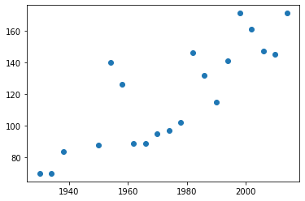

```python
plt.scatter(x='Year', y='GoalsScored', data=cups)
```

### observations

- the number of goals increased at the year increased
- the most amount of goals scored is greater than 160 after the late 1990s

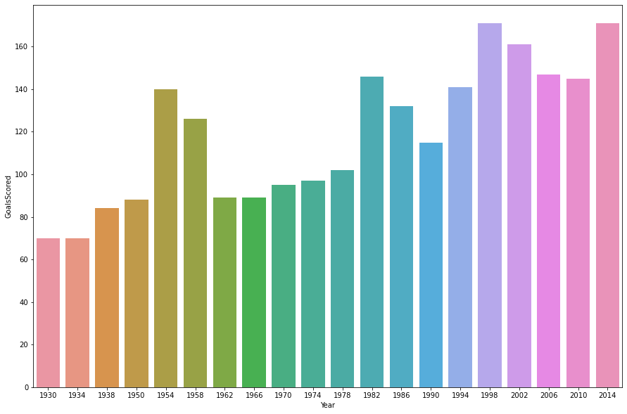

```python
fig, ax=plt.subplots(figsize=(15,10))
sns.barplot(data=cups, x='Year', y='GoalsScored')
```

This graph shows a clearer representation of the scatter plot- the most goals was scored in 1998 and 2014.

### check missing values

```python
cups.isnull().sum()
```

```
Year              0
Country           0
Winner            0
Runners-Up        0
Third             0
Fourth            0
GoalsScored       0
QualifiedTeams    0
MatchesPlayed     0
Attendance        0
dtype: int64
```

```python
players.isnull().sum()
```

```
RoundID              0
MatchID              0
Team Initials        0
Coach Name           0
Line-up              0
Shirt Number         0
Player Name          0
Position         33641
Event            28715
dtype: int64
```

```python
# create a function for percentage of missing data
def missing(players):
    print (round((players.isnull().sum() * 100/ len(players)),2).sort_values(ascending=False))

missing(players)
```

```
Position         89.04
Event            76.00
RoundID           0.00
MatchID           0.00
Team Initials     0.00
Coach Name        0.00
Line-up           0.00
Shirt Number      0.00
Player Name       0.00
dtype: float64
```

```python
# need to change missing values into those that are the mode -- mode imputation

players['Position'].value_counts()
```

```
GK     2441
C      1510
GKC     192
Name: Position, dtype: int64
```

```python
players['Position'].replace('', np.NaN).head()
```

```
0     GK
1     GK
2    NaN
3    NaN
4    NaN
Name: Position, dtype: object
```

```python
# fill NaN values with 2441 index[0] value
df = players['Position'].value_counts().index[0]
players['Position'].fillna(df, inplace=True)
players['Position'].head()
```

```
0    GK
1    GK
2    GK
3    GK
4    GK
Name: Position, dtype: object
```

```python
players['Event'].replace('', np.NaN).head()
```

```
0     NaN
1     NaN
2    G40'
3    G70'
4     NaN
Name: Event, dtype: object
```

```python
# do the same thing -- mode imputation -- for players['Event']
df1= players['Event'].value_counts().index[0]
players['Event'].fillna(df1, inplace=True)
players['Event'].head()
```

```
0    OH46'
1    OH46'
2     G40'
3     G70'
4    OH46'
Name: Event, dtype: object
```

```python
# double check that all missing values are accounted for

def missing(players):
    print (round((players.isnull().sum() * 100/ len(players)),2).sort_values(ascending=False))

missing(players)
```

```
RoundID          0.0
MatchID          0.0
Team Initials    0.0
Coach Name       0.0
Line-up          0.0
Shirt Number     0.0
Player Name      0.0
Position         0.0
Event            0.0
dtype: float64
```

### check correlation

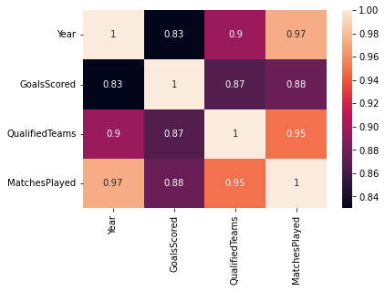

```python
sns.heatmap(cups.corr(), annot= True)

plt.show()
```

### Find outliers using boxplot

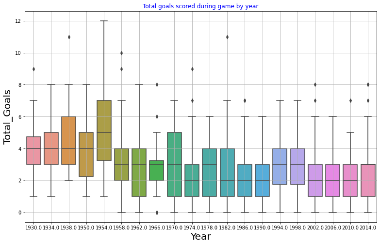

```python
matches["total_goals"] = matches["Home Team Goals"] + matches["Away Team Goals"]

plt.figure(figsize=(13,8))
sns.boxplot(y=matches["total_goals"],
            x=matches["Year"])
plt.grid(True)
plt.title("Total goals scored during game by year",color='b')
plt.xlabel("Year", fontsize=20)
plt.ylabel("Total_Goals", fontsize=20)
plt.show()
```

use multivariate graphs to answer q's

## 1) which country scored the most amount of goals?

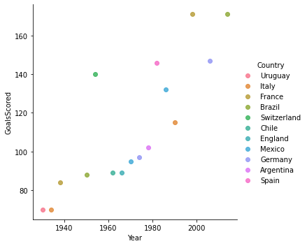

```python
sns.lmplot(x='Year', y='GoalsScored', hue='Country',
           data=cups.loc[cups['Country'].isin(['Uruguay', 'Italy', 'France', 'Brazil', 'Switzerland', 'Chile', 'England', 'Mexico', 'Germany', 'Argentina', 'Spain', 'Mexico'])],
           fit_reg=False)
```

## 2) matches with highest attendance

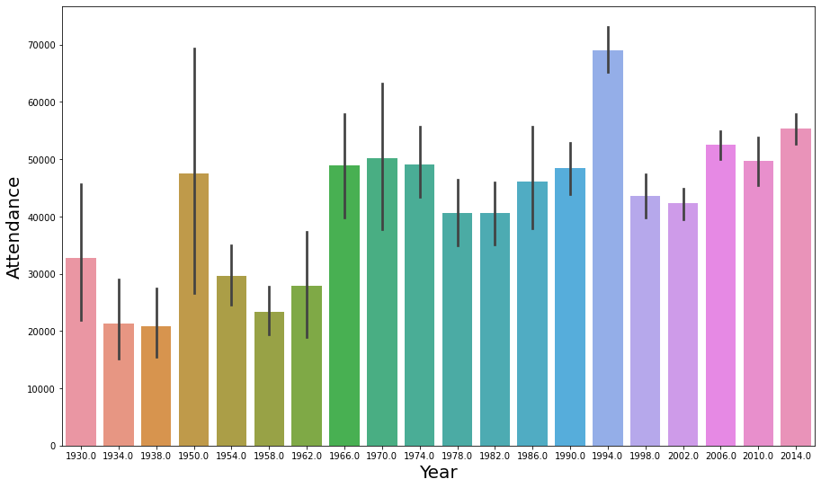

```python
plt.figure(figsize=(15,9))
ax= sns.barplot(x=matches['Year'], y=matches['Attendance'])
plt.xlabel("Year", fontsize=20)
plt.ylabel("Attendance", fontsize=20)


plt.show()
```

```python
# find match with highest attendance
matches[matches['Attendance'] == matches['Attendance'].max()]
```

|  | Year | Datetime | Stage | Stadium | City | Home Team Name | Home Team Goals | Away Team Goals | Away Team Name | Win conditions | ... | Half-time Home Goals | Half-time Away Goals | Referee | Assistant 1 | Assistant 2 | RoundID | MatchID | Home Team Initials | Away Team Initials | total_goals |
| --- | --- | --- | --- | --- | --- | --- | --- | --- | --- | --- | --- | --- | --- | --- | --- | --- | --- | --- | --- | --- | --- |
| 74 | 1950.0 | 16 Jul 1950 - 15:00 | Group 6 | Maracan� - Est�dio Jornalista M�rio Filho | Rio De Janeiro | Uruguay | 2.0 | 1.0 | Brazil |  | ... | 0.0 | 0.0 | READER George (ENG) | ELLIS Arthur (ENG) | MITCHELL George (SCO) | 209.0 | 1190.0 | URU | BRA | 3.0 |

1 rows × 21 columns

```python
print(matches['Attendance'].loc[[74]])
```

```
74    173850.0
Name: Attendance, dtype: float64
```

**The match with the most attendance (173,850 people) was the Uruguay x Brazil match in 1950**

### 3) Cities with highest world cup matches

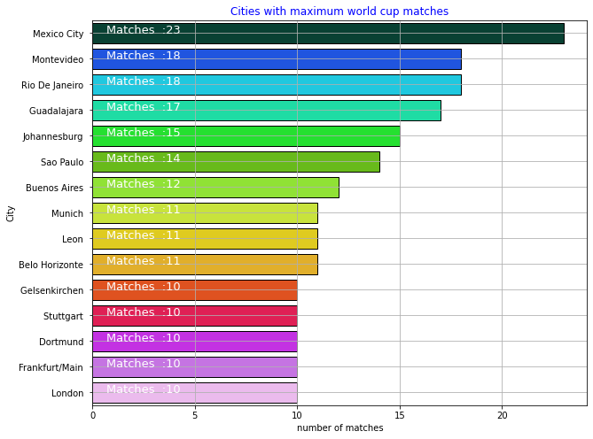

```python
mat_c = matches["City"].value_counts().reset_index()
plt.figure(figsize=(10,8))
ax = sns.barplot(y=mat_c["index"][:15],x = mat_c["City"][:15],palette="gist_ncar",
                 linewidth=1,edgecolor=[c for c in "k"*15])
plt.xlabel("number of matches")
plt.ylabel("City")
plt.grid(True)
plt.title("Cities with maximum world cup matches",color='b')

for i,j in enumerate("Matches  :" + mat_c["City"][:15].astype(str)):
    ax.text(.7,i,j,fontsize = 13,color="w")
plt.show()
```

**This graph shows that Mexico City had the most amount of matches -- 23** I used the follow along video for this graph for this module in MIT's Applied Data Science Program

### 4) Attendance average by city

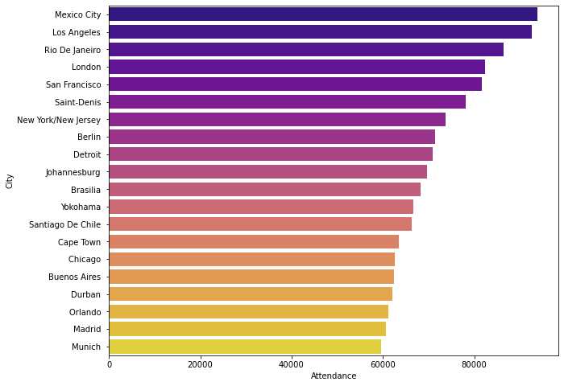

```python
# first 20 cities by attendance
ct_at = matches.groupby("City")["Attendance"].mean().reset_index()
ct_at = ct_at.sort_values(by="Attendance",ascending=False)
ct_at
plt.figure(figsize=(10,8))
ax = sns.barplot('Attendance', 'City', data=ct_at[:20], palette= 'plasma' )
plt.show()
```

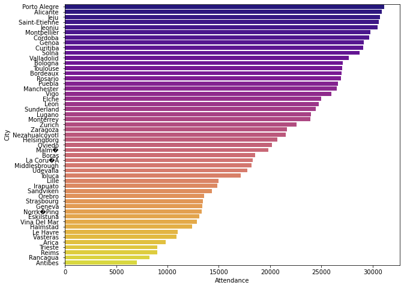

```python
# show the tail end of the graph
plt.figure(figsize=(10,8))
ax = sns.barplot(x=ct_at['Attendance'][100:] , y= ct_at['City'][100:], palette='plasma')
plt.show()
```

#### Observations

- Mexico City, Los Angeles and Rio de Janiero had the highest attendance averages

### 5) Find teams with most world cup victories

```python
cups['Winner'].unique()
```

```
array(['Uruguay', 'Italy', 'Germany FR', 'Brazil', 'England', 'Argentina',
       'France', 'Spain', 'Germany'], dtype=object)
```

```python
# replace Germany FR with Germany
cups["Winner"]=cups["Winner"].replace("Germany FR","Germany")
cups["Runners-Up"]=cups["Runners-Up"].replace("Germany FR","Germany")
cups['Winner'].unique()
```

```
array(['Uruguay', 'Italy', 'Germany', 'Brazil', 'England', 'Argentina',
       'France', 'Spain'], dtype=object)
```

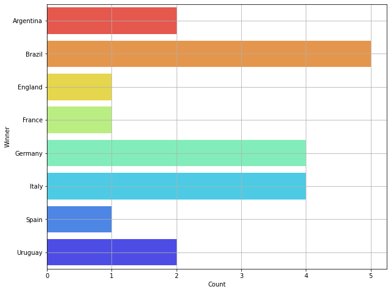

```python
c  = cups.groupby("Winner")['Year'].count().reset_index()

plt.figure(figsize=(10,8))
ax = sns.barplot(x=c['Year'], y= c['Winner'], data=c,
            palette="jet_r",
            alpha=.8,
            linewidth=2)
plt.xlabel('Count')
plt.grid(True)
plt.show()
```

### 6) compare home team vs away team wins

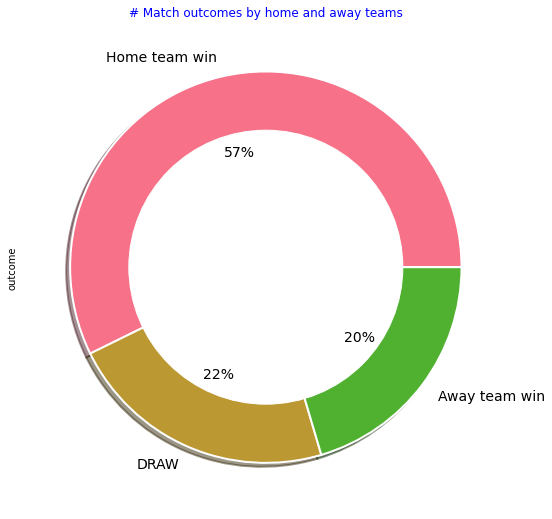

```python
def label(matches):
    if matches["Home Team Goals"] > matches["Away Team Goals"]:
        return "Home team win"
    if matches["Away Team Goals"] > matches["Home Team Goals"]:
        return "Away team win"
    if matches["Home Team Goals"] == matches["Away Team Goals"]:
        return "DRAW"

matches["outcome"] = matches.apply(lambda matches:label(matches),axis=1)
plt.figure(figsize=(9,9))
matches["outcome"].value_counts().plot.pie(autopct="%1.0f%%",fontsize =14,
                                           colors = sns.color_palette("husl"),
                                           wedgeprops={"linewidth":2,"edgecolor":"white"},
                                           shadow=True)
circ = plt.Circle((0,0),.7,color="white")
plt.gca().add_artist(circ)
plt.title("# Match outcomes by home and away teams",color='b')
plt.show()
```

**57 % of matches were home team wins**